# KOSPI_GARCH

Ji Jung

3/25/2022

이상 현상 탐지(anomaly detection)란 특이값(Outlier)를 탐지하는 기법입니다. 이번에는 코로나 사태 이후 KOSPI에서 발생한 특이값을 탐지하고 그리고 GARCH기법을 이용해서 미래 주가의 분산성과 변동성에 대해 예측해보겠습니다.

이상 현상 탐지에는 anomalize 패키지가 쓰입니다. 우선 이번에 쓰일 코스피는 2020-01-01 이후입니다.

# Part 1 코스피 주가 이상 현상 탐지 (Anomaly Detection)

### 코스피 주가 불러오기

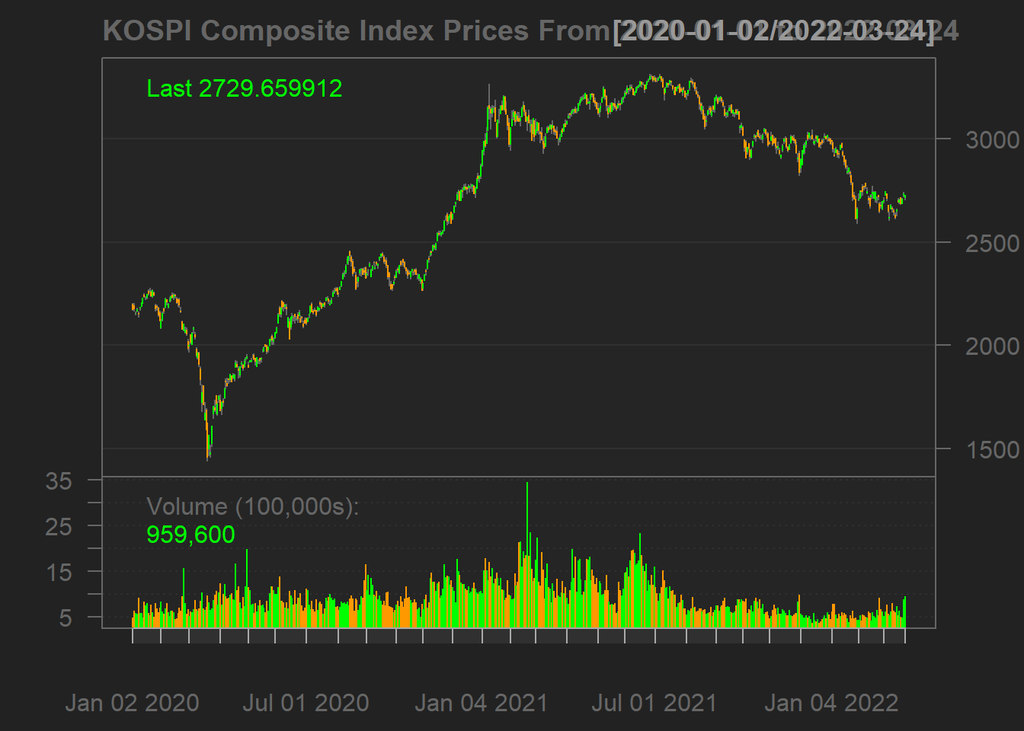

```r
chartSeries(KOSPI_source, name =
              "KOSPI Composite Index Prices From 2020-01-01 to 2022-03-24")
```

### Data Transformation

```r
KOSPI <- Cl(KOSPI_source)
names(KOSPI) <- "KOSPI"
dates <- index(KOSPI)
KOSPI <- as.data.frame(KOSPI)
KOSPI <- cbind(date = dates, KOSPI)
```

### Convert dataframe to a tibble

```r
KOSPI_ts<- as.tibble(KOSPI)
class(KOSPI_ts)
```

```
## [1] "tbl_df"     "tbl"        "data.frame"
```

get_time_scale_template()는 데이터의 스케일에 따라 논리적으로 frequency와 trend 범위를 결정할 수 있는 명령어입니다.

```r
get_time_scale_template()
```

```
## # A tibble: 8 x 3
##   time_scale frequency trend
##   <chr>      <chr>     <chr>
## 1 second     1 hour    12 hours
## 2 minute     1 day     14 days
## 3 hour       1 day     1 month
## 4 day        1 week    3 months
## 5 week       1 quarter 1 year
## 6 month      1 year    5 years
## 7 quarter    1 year    10 years
## 8 year       5 years   30 years
```

### Adjusting Local Parameters

```r
KOSPI_ts_anomalized <- KOSPI_ts %>%
  time_decompose(KOSPI, merge = TRUE,
                 method    = "stl",
                 frequency = "1 week",
                 trend     = "3 months") %>%
  anomalize(remainder,alpha = 0.05, max_anoms = 0.2) %>%
  time_recompose()
```

### Including Plots

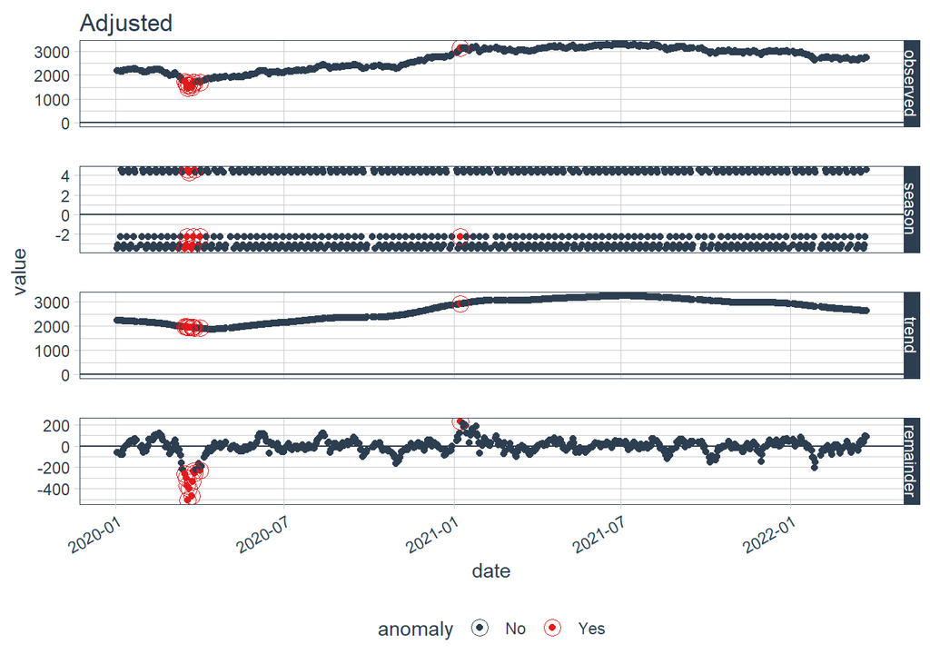

```r
KOSPI_stl <- KOSPI_ts_anomalized %>%
  plot_anomaly_decomposition() +
  ggtitle("Adjusted")
KOSPI_stl
```

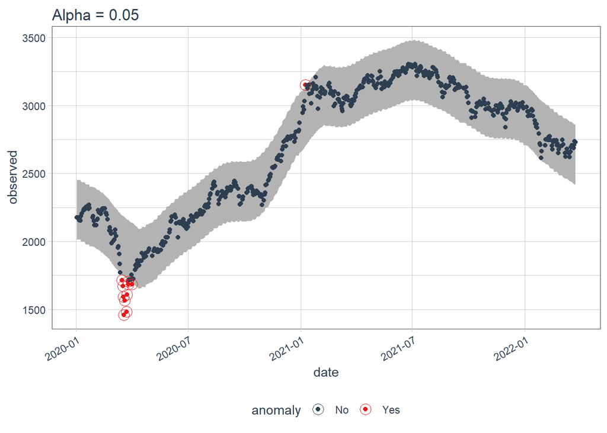

```r
KOSPI_ts_anomalized %>%
  plot_anomalies(time_recomposed = TRUE) +
  ggtitle("Alpha = 0.05")
```

### Extracting the Anomalous Data Points

```r
KOSPI_Anomalous_Data_Points <- KOSPI_ts_anomalized %>% dplyr::filter(anomaly == 'Yes')
KOSPI_Anomalous_Data_Points
```

```
## # A time tibble: 11 x 11
## # Index: date
##    date       KOSPI observed season trend remainder remainder_l1 remainder_l2
##    <date>     <dbl>    <dbl>  <dbl> <dbl>     <dbl>        <dbl>        <dbl>
##  1 2020-03-16 1715.    1715.  -3.48 1979.     -261.        -222.         218.
##  2 2020-03-17 1672.    1672.  -3.10 1974.     -298.        -222.         218.
##  3 2020-03-18 1591.    1591.  -2.24 1969.     -375.        -222.         218.
##  4 2020-03-19 1458.    1458.   4.55 1963.     -510.        -222.         218.
##  5 2020-03-20 1566.    1566.   4.27 1958.     -396.        -222.         218.
##  6 2020-03-23 1482.    1482.  -3.48 1953.     -467.        -222.         218.
##  7 2020-03-24 1610.    1610.  -3.10 1948.     -335.        -222.         218.
##  8 2020-03-25 1705.    1705.  -2.24 1943.     -236.        -222.         218.
##  9 2020-03-26 1686.    1686.   4.55 1939.     -257.        -222.         218.
## 10 2020-04-01 1685.    1685.  -2.24 1920.     -232.        -222.         218.
## 11 2021-01-08 3152.    3152.  -2.24 2927.      228.        -222.         218.
## # ... with 3 more variables: anomaly <chr>, recomposed_l1 <dbl>,
## #   recomposed_l2 <dbl>
```

## Part 2 GARCH 모델로 KOSPI 주가변동성 예측

Part 2에서는 GARCH 모델을 기반으로 KOSPI 주가의 분산을 예측해보겠습니다. 주가의 분산도가 클면 변동성에도 영향을 미치며, 이 변동성을 예측하기 위한 모델이 GARCH입니다.

### 정상시계열

Augmented Dickey–Fuller 검정을 실시하여 KOSPI 데이터가 정상시계열인지 확인합니다.

```r
# Augmented Dickey–Fuller test
adf.test(KOSPI_source$KS11.Adjusted)
```

```
##
##  Augmented Dickey-Fuller Test
##
## data:  KOSPI_source$KS11.Adjusted
## Dickey-Fuller = -0.73203, Lag order = 8, p-value = 0.9677
## alternative hypothesis: stationary
```

```r
adf.test(KOSPI.r)
```

```
##
##  Augmented Dickey-Fuller Test
##
## data:  KOSPI.r
## Dickey-Fuller = -7.287, Lag order = 8, p-value = 0.01
## alternative hypothesis: stationary
```

변환된 시계열을 Augmented Dickey–Fuller 검정한 결과 P-value가 0.01보다 적게 나와 정상 시계열로 변환됐음을 알수있습니다.

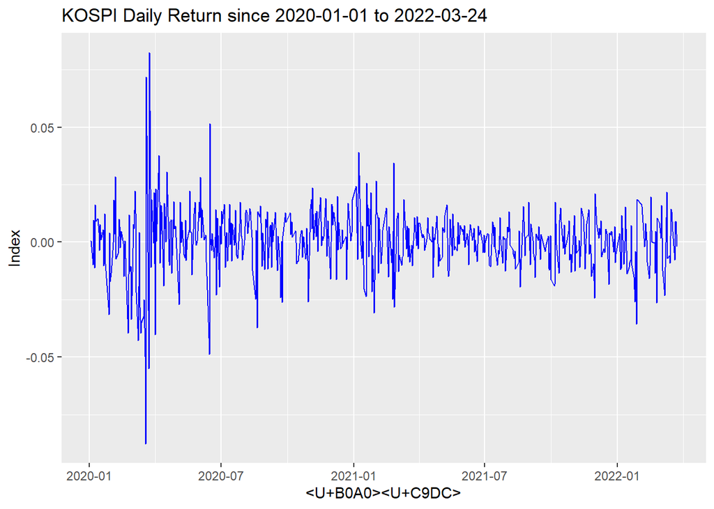

### GARCH(1,1) 모형

```r
AIC(garch.11)
```

```
## [1] -3289.456
```

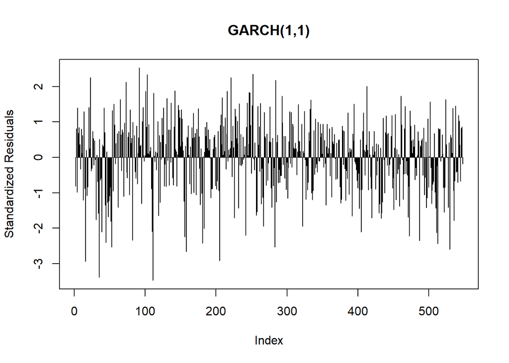

```r
plot(residuals(garch.11),type='h',ylab='Standardized Residuals', main='GARCH(1,1)')
```

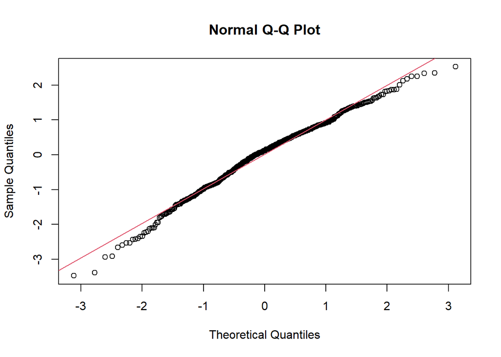

```r
qqnorm(residuals(garch.11)); qqline(residuals(garch.11), col = 2)
```

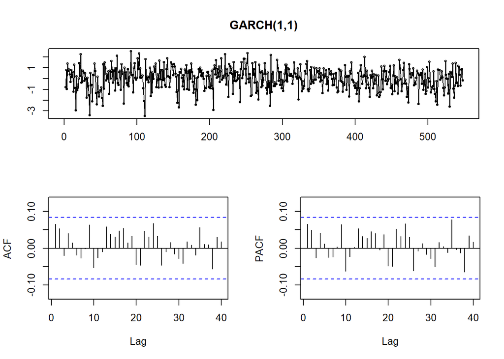

```r
tsdisplay(residuals(garch.11), lag.max = 40, main="GARCH(1,1)")
```

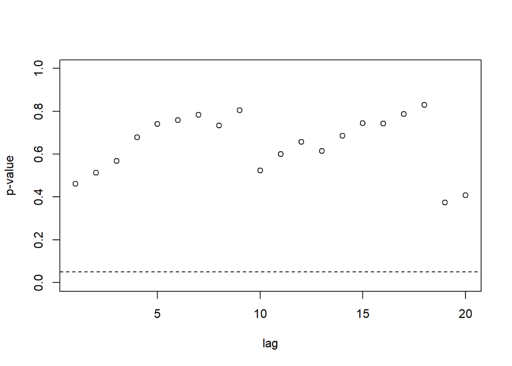

```r
gBox(garch.11,method='squared')
```

모형 적합도(Goodness of fit)를 보면 Squared standardized residuals가 P-value인 0.05보다 높으므로 봐서 GARCH(1,1)모형이 적합합니다. Squared standardized residuals 독립적임을 알수있습니다.

### GARCH 예측 모델

최종 모델 사양 정의

```r
Garch11.spec <- ugarchspec(mean.model=list(armaOrder=c(1,1)),
                            variance.model=list(model="gjrGARCH", garchOrder=c(1,1)),
                            distribution.model = "sstd")
Garch11.fit <- ugarchfit(spec=Garch11.spec, data=KOSPI.r)
```

평균 및 변동성 역학 분석

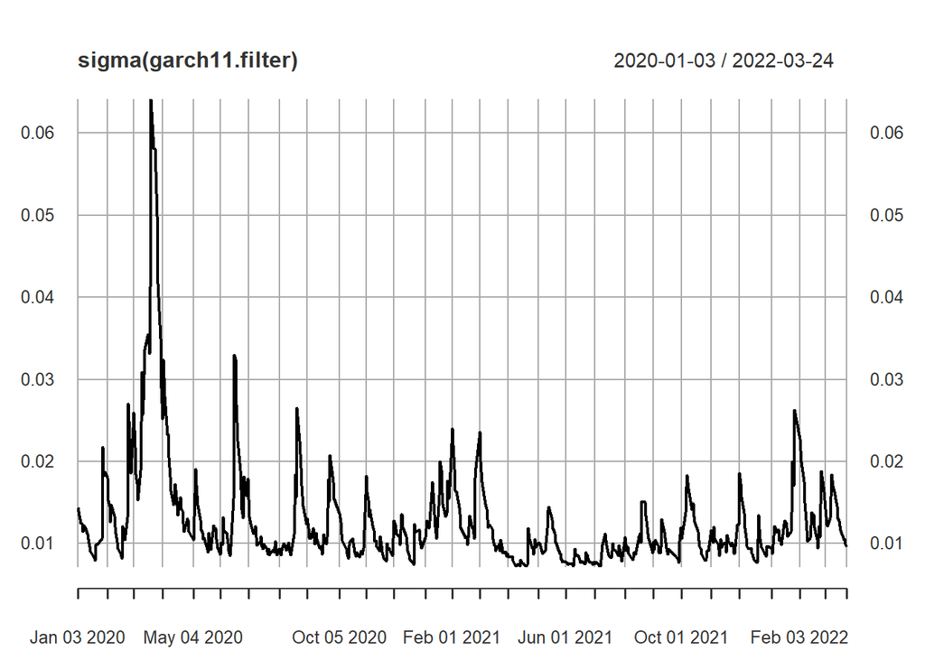

```r
setfixed(Garch11.spec) <- as.list(coef(Garch11.fit))
garch11.filter <- ugarchfilter(data = KOSPI.r, spec = Garch11.spec)
plot(sigma(garch11.filter))
```

미래 수익에 대한 예측 - 30일로 세팅

```
##        2022-03-24  2022-03-24
## T+1  7.305575e-06 0.008853717
## T+2  3.382974e-05 0.009314376
## T+3  1.435621e-05 0.009715895
## T+4  2.865329e-05 0.010068502
## T+5  1.815666e-05 0.010379972
## T+6  2.586308e-05 0.010656391
## T+7  2.020518e-05 0.010902639
## T+8  2.435910e-05 0.011122699
## T+9  2.130937e-05 0.011319875
## T+10 2.354842e-05 0.011496941
## T+11 2.190455e-05 0.011656251
## T+12 2.311145e-05 0.011799819
## T+13 2.222537e-05 0.011929386
## T+14 2.287591e-05 0.012046462
## T+15 2.239830e-05 0.012152365
## T+16 2.274895e-05 0.012248253
## T+17 2.249151e-05 0.012335146
## T+18 2.268052e-05 0.012413947
## T+19 2.254175e-05 0.012485457
## T+20 2.264363e-05 0.012550388
## T+21 2.256883e-05 0.012609377
## T+22 2.262375e-05 0.012662993
## T+23 2.258343e-05 0.012711747
## T+24 2.261303e-05 0.012756095
## T+25 2.259130e-05 0.012796449
## T+26 2.260726e-05 0.012833182
## T+27 2.259554e-05 0.012866626
## T+28 2.260414e-05 0.012897085
## T+29 2.259783e-05 0.012924830
## T+30 2.260246e-05 0.012950110
```

Sigma는 예측 변동성 값입니다.

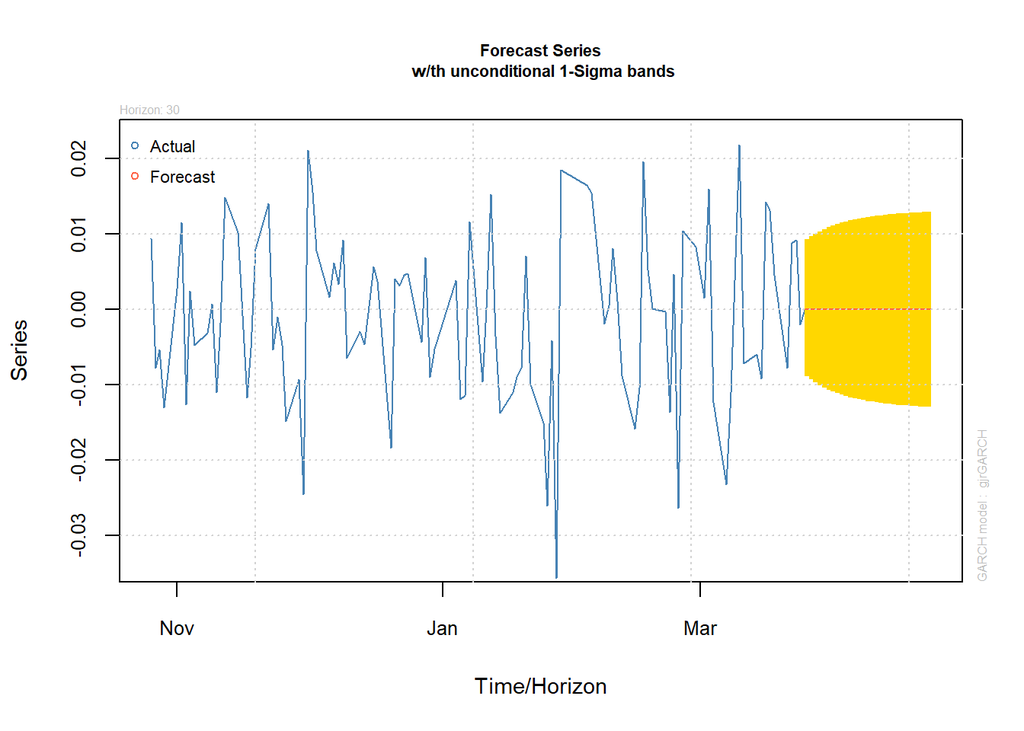

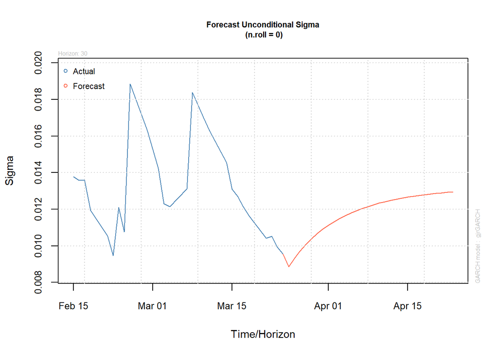

```r
plot(garch11.forecast.30, which=1);plot(garch11.forecast.30, which=3)
```

## Forecasting using Bootstrap

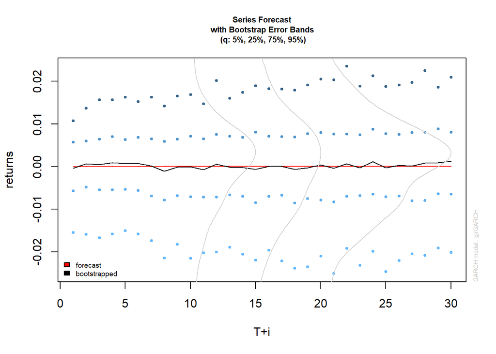

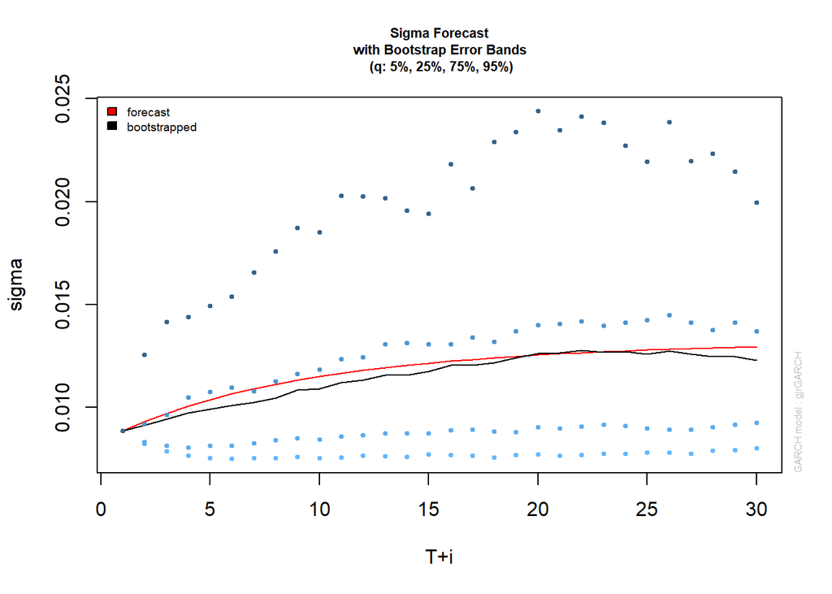

```r
forecast_boot <- ugarchboot(Garch11.fit,data = na.omit(KOSPI.r), method = c("Partial", "Full")[1], n.ahead = 30, n.bootpred = 500)
plot(forecast_boot,which=2);plot(forecast_boot,which=3)
```